# Relatório Sintético Geral - Autoavaliação UFRPE 2020

Este relatório apresenta os resultados quantitativos da autoavaliação 2020 da Universidade Federal Rural de Pernambuco (UFRPE), conduzida pela Comissão Própria de Avaliação (CPA). Neste ano foram avaliadas as Políticas Acadêmicas da instituição, contemplando cinco temáticas: políticas de ensino, de pesquisa, de extensão, de assistência estudantil, e também a comunicação institucional.

Os questionários foram aplicados durante a pandemia causada pela Covid-19. De tal forma, toda mobilização e sensibilização para participação na autoavaliação foram virtuais, através das mídias sociais e dos e-mails institucionais. Assim, os resultados aqui apresentados refletem, também, esse momento vivido por toda comunidade universitária.

A Seção 1 apresenta uma visão geral dos resultados da autoavaliação com base nas médias das respostas obtidas. A Seção 2 contém os resultados completos dos questionários de autoavaliação aplicados no Campus Dois Irmãos, na Unidade Acadêmica do Cabo de Santo Agostinho (UACSA) e na Unidade Acadêmica de Serra Talhada (UAST). Os resultados completos da Unidade Acadêmica de Educação à Distância e Tecnologia (UAEADTec) são apresentados na Seção 3. Em ambos os casos, os resultados são classificados por temática e por segmento (estudantes, docentes e técnicos). Considerações sobre a metodologia de avaliação são apresentadas na Seção 4. Por último, a Seção 5 conclui este relatório.

# 1 Visão Geral

A Autoavaliação 2020 da UFRPE contou com a participação de 2000 estudantes, 484 docentes e 257 técnicos, englobando o Campus Dois Irmãos, a Unidade Acadêmica do Cabo de Santo Agostinho (UACSA), a Unidade Acadêmica de Serra Talhada (UAST) e a Unidade Acadêmica de Educação à Distância e Tecnologia (UAEADTec)

A seguir são apresentadas as médias dos resultados da avaliação feita por cada segmento acadêmico.

## 1.1 Estudantes (Campus Dois Irmãos, UACSA, UAST)

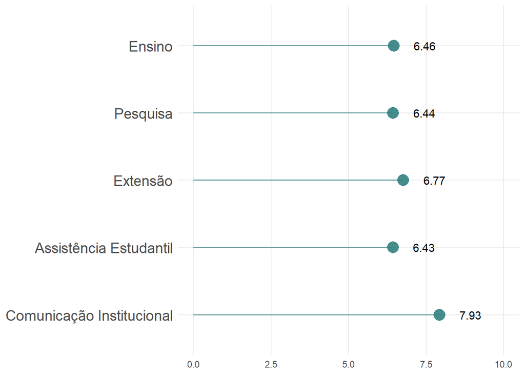

Os dados apresentados acima apontam a média das respostas de cada tema, dadas pelos estudantes dos Campus Dois Irmãos, UACSA e UAST. Durante o período de aplicação do questionário, essas unidades e a sede contavam com 9787 estudantes aptos a participar da avaliação, dos quais 1742 (17.8%) responderam ao questionário. A participação média foi de 42,5 estudantes por curso, com desvio padrão amostral de 28,4.

Considerando a totalidade das respostas desses estudantes, referentes às Políticas Acadêmicas da UFRPE, 2.75% das respostas foram “péssimo”, 5.91% foram “ruim”, 19.11% foram “regular”, 29.79% foram “bom”, 19.76% foram “excelente”, e 22.68% foram outras opções de resposta.

## 1.2 Estudantes (UAEADTec)

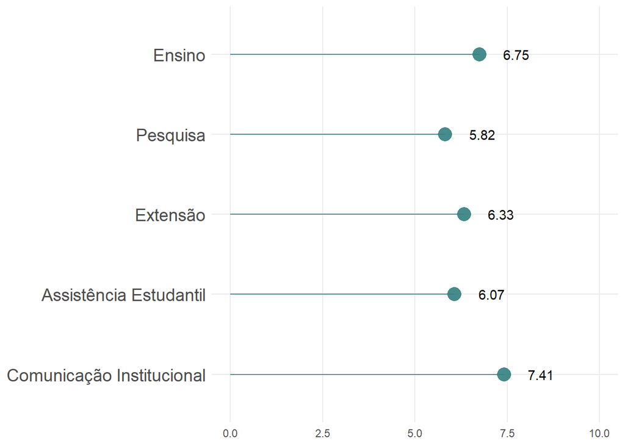

Os dados apresentados acima apontam a média das respostas de cada tema, dadas pelos estudantes da Unidade Acadêmica de Educação à Distância e Tecnologia (UAEADTec). Durante o período de aplicação do questionário, a UAEADTec contava com 629 estudantes aptos a participar da avaliação, dos quais 258 (41.02%) responderam ao questionário. A participação média foi de 32,3 estudantes por curso, com desvio padrão amostral de 18,9.

Considerando a totalidade das respostas desses estudantes, referentes às Políticas Acadêmicas da UFRPE, 3.94% das respostas foram “péssimo”, 4.71% foram “ruim”, 16.87% foram “regular”, 33.79% foram “bom”, 16.49% foram “excelente”, e 24.21% foram outras opções de resposta.

## 1.3 Docentes (Campus Dois Irmãos, UACSA, UAST)

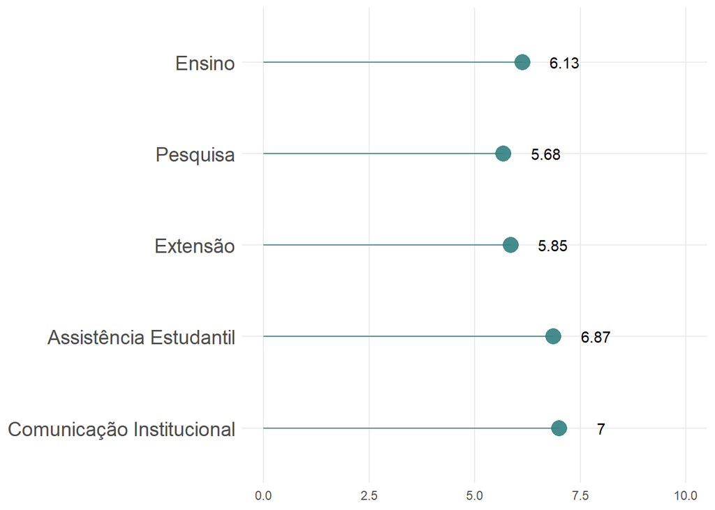

Os dados apresentados acima apontam a média das respostas de cada tema, dadas pelos servidores docentes dos Campus Dois Irmãos, UACSA e UAST. Durante o período de aplicação do questionário, essas unidades e a sede contavam com 1040 docentes aptos a participar da avaliação, dos quais 449 (43.17%) responderam ao questionário.

Considerando a totalidade das respostas desses docentes, referentes às Políticas Acadêmicas da UFRPE, 3.45% das respostas foram “péssimo”, 8.29% foram “ruim”, 25.33% foram “regular”, 33.35% foram “bom”, 10.04% foram “excelente”, e 19.54% foram outras opções de resposta.

## 1.4 Docentes (UAEADTec)

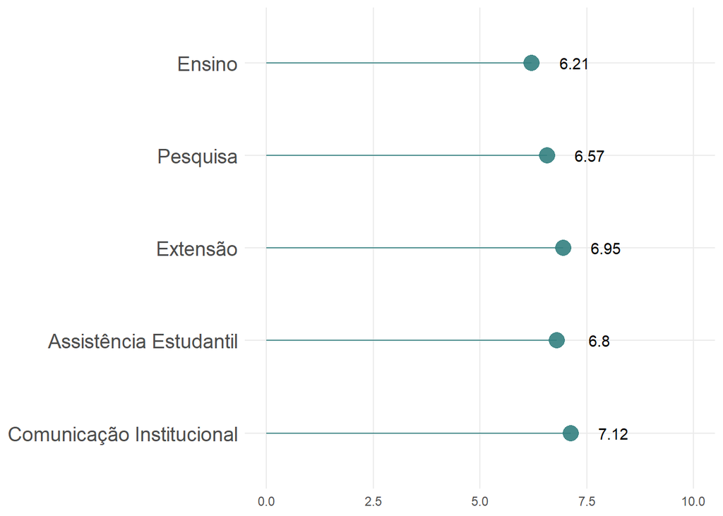

Os dados apresentados acima apontam a média das respostas de cada tema, dadas pelos servidores docentes da Unidade Acadêmica de Educação à Distância e Tecnologia (UAEADTec). Durante o período de aplicação do questionário, a UAEADTec contava com 38 docentes aptos a participar da avaliação, dos quais 35 (92.11%) responderam ao questionário.

Considerando a totalidade das respostas desses docentes, referentes às Políticas Acadêmicas da UFRPE, 3.25% das respostas foram “péssimo”, 7.17% foram “ruim”, 17.54% foram “regular”, 38.66% foram “bom”, 15.41% foram “excelente”, e 17.98% foram outras opções de resposta.

## 1.5 Técnicos (Campus Dois Irmãos, UACSA, UAST)

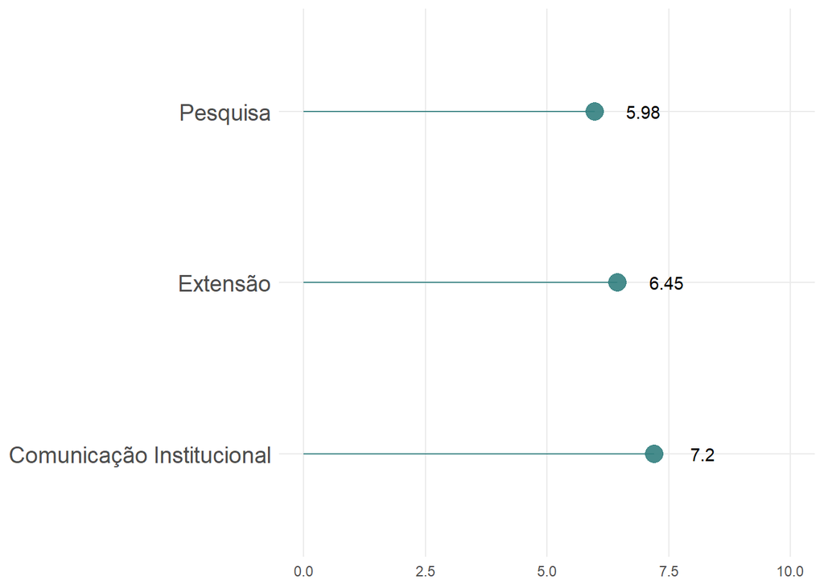

Os dados apresentados acima apontam a média das respostas de cada tema, dadas pelos servidores técnicos dos Campus Dois Irmãos, UACSA e UAST. Durante o período de aplicação do questionário, essas unidades e a sede contavam com 985 técnicos aptos a participar da avaliação, dos quais 244 (24.77%) responderam ao questionário.

Considerando a totalidade das respostas desses técnicos, referentes às Políticas Acadêmicas da UFRPE, 2.64% das respostas foram “péssimo”, 4.92% foram “ruim”, 15.62% foram “regular”, 29% foram “bom”, 14.16% foram “excelente”, e 33.66% foram outras opções de resposta.

*Observação: o questionário aplicado aos técnicos não contemplou as temáticas Ensino e Assistência Estudantil.*

## 1.6 Técnicos (UAEADTec)

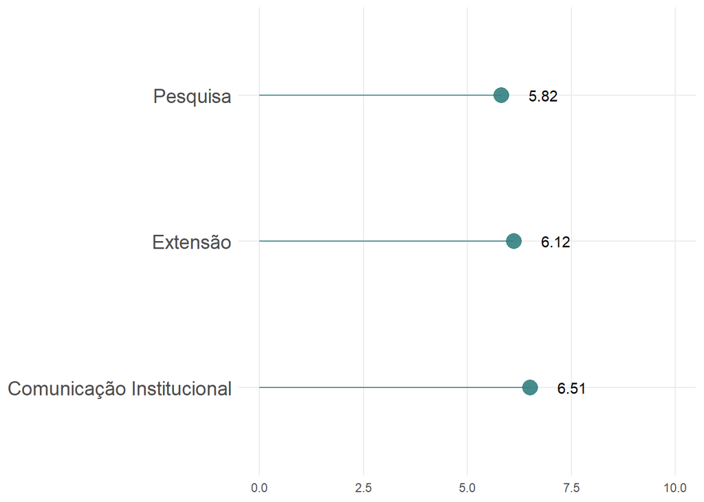

Os dados apresentados acima apontam a média das respostas de cada tema, dadas pelos servidores técnicos da Unidade Acadêmica de Educação à Distância e Tecnologia (UAEADTec). Durante o período de aplicação do questionário, a UAEADTec contava com 13 técnicos aptos a participar da avaliação, dos quais 13 (100%) responderam ao questionário.

Considerando a totalidade das respostas desses técnicos, referentes às Políticas Acadêmicas da UFRPE, 2.4% das respostas foram “péssimo”, 11.06% foram “ruim”, 18.75% foram “regular”, 28.85% foram “bom”, 12.02% foram “excelente”, e 26.92% foram outras opções de resposta.

*Observação: o questionário aplicado aos técnicos não contemplou as temáticas Ensino e Assistência Estudantil.*

# 2 Resultados da Avaliação das Políticas Acadêmicas (Campus Dois Irmãos, UACSA e UAST)

Esta seção apresenta os resultados referentes à avaliação das políticas acadêmicas da UFRPE, conforme respondido pelos integrantes do Campus Dois Irmãos, da Unidade Acadêmica do Cabo de Santo Agostinho (UACSA) e da Unidade Acadêmica de Serra Talhada (UAST). Os resultados referentes à Unidade Acadêmica de Educação à Distância e Tecnologia (UAEADTec) são apresentados na Seção 3.

A seguir são apresentados os resultados classificados por temática: ensino, pesquisa, extensão, assistência estudantil e comunicação institucional. Em cada temática, os resultados são separados por segmentos: estudantes, docentes e técnicos. Essa separação é feita visto que as perguntas são diferentes para cada segmento. Em cada combinação temática/segmento, os resultados são apresentados em ordem decrescente de média.

## 2.1 Avaliação do Ensino (Campus Dois Irmãos, UACSA e UAST)

### 2.1.1 Estudantes

| Média | Item avaliado | Péssimo (0) | Ruim (2.5) | Regular (5) | Bom (7.5) | Excelente (10) | OOR* |
| --- | --- | --- | --- | --- | --- | --- | --- |
| 7.8 | Sistema de Seleção Unificada (Sisu) como a principal forma de ingresso nos cursos de graduação da UFRPE | 19 | 54 | 265 | 714 | 645 | 45 |
| 7.2 | Diversificação de instrumentos avaliativos | 24 | 87 | 416 | 766 | 432 | 17 |
| 7.1 | Práticas de interdisciplinaridade no seu curso | 20 | 77 | 418 | 736 | 386 | 105 |
| 7.1 | Diversificação de estratégias de ensino | 23 | 90 | 442 | 730 | 430 | 27 |
| 7.0 | Acesso ao Projeto Pedagógico do seu Curso (PPC) | 34 | 75 | 402 | 685 | 346 | 200 |
| 7.0 | Práticas de integração entre atividades de ensino e Pesquisa | 26 | 96 | 373 | 645 | 327 | 275 |
| 6.9 | Atuação da Comissão de Orientação e Acompanhamento Acadêmico (COAA) | 39 | 54 | 206 | 396 | 217 | 830 |
| 6.8 | Práticas de integração entre atividades de ensino e extensão | 26 | 106 | 360 | 576 | 269 | 405 |
| 6.7 | Articulação entre teoria e prática nas disciplinas | 28 | 137 | 521 | 712 | 332 | 12 |
| 6.5 | Ações institucionais de prevenção à retenção em disciplinas do seu curso | 52 | 114 | 340 | 561 | 230 | 445 |
| 6.4 | Ambiente Virtual de Aprendizagem (AVA) nas atividades de ensino | 52 | 134 | 495 | 624 | 255 | 182 |
| 6.3 | Oferta de bolsas para o programa de monitoria da UFRPE | 55 | 164 | 468 | 545 | 233 | 277 |
| 6.1 | Ações institucionais de prevenção à evasão no seu curso | 79 | 183 | 396 | 461 | 232 | 391 |
| 4.1 | Oferta de vagas em programas de intercâmbio nacional para graduandos | 216 | 273 | 329 | 183 | 67 | 674 |
| 3.9 | Oferta de vagas em programas de intercâmbio internacional para graduandos | 263 | 281 | 321 | 164 | 85 | 628 |

*OOR: Outras opções de resposta. Para saber qual o texto da(s) respostas(s) de uma questão em específico, posicione o cursor do mouse sobre o valor correspondente na última coluna.

### 2.1.2 Docentes

| Média | Item avaliado | Péssimo (0) | Ruim (2.5) | Regular (5) | Bom (7.5) | Excelente (10) | OOR* |
| --- | --- | --- | --- | --- | --- | --- | --- |
| 7.2 | Articulação entre teoria e prática nas disciplinas | 3 | 9 | 97 | 270 | 66 | 4 |
| 7.0 | Atuação da Comissão de Orientação e Acompanhamento Acadêmico (COAA) | 4 | 23 | 77 | 177 | 60 | 108 |
| 6.9 | Práticas de integração entre atividades de ensino e Pesquisa | 4 | 20 | 109 | 232 | 63 | 21 |
| 6.8 | Sistema de Seleção Unificada (Sisu) como a principal forma de ingresso nos cursos de graduação da UFRPE. | 6 | 33 | 111 | 179 | 86 | 34 |
| 6.4 | Ações institucionais de prevenção à retenção | 9 | 24 | 124 | 185 | 37 | 70 |
| 6.4 | Ambiente Virtual de Aprendizagem (AVA) nas atividades de ensino | 8 | 30 | 100 | 155 | 37 | 119 |
| 6.3 | Ações institucionais de prevenção à evasão | 8 | 22 | 145 | 176 | 26 | 72 |
| 6.3 | Oferta institucional de formação didático-pedagógica contínua na UFRPE | 8 | 31 | 137 | 169 | 34 | 70 |
| 6.2 | Oferta de bolsas para o programa de monitoria da UFRPE | 7 | 42 | 148 | 186 | 34 | 32 |
| 6.2 | Práticas de interdisciplinaridade nos cursos em que você atua | 2 | 42 | 152 | 183 | 32 | 38 |
| 6.2 | Práticas de integração entre atividades de ensino e extensão | 6 | 50 | 149 | 163 | 51 | 30 |
| 5.6 | Como a UFRPE acompanha o estudante egresso | 13 | 45 | 115 | 94 | 25 | 157 |
| 5.5 | Ações institucionais de capacitação para práticas pedagógicas voltadas aos estudantes com deficiência | 15 | 48 | 128 | 102 | 19 | 137 |
| 4.5 | Oferta de vagas em programas de intercâmbio nacional para docentes | 32 | 66 | 105 | 57 | 10 | 179 |
| 4.4 | Oferta de vagas em programas de intercâmbio internacional para docentes | 43 | 64 | 114 | 57 | 11 | 160 |

*OOR: Outras opções de resposta. Para saber qual o texto da(s) respostas(s) de uma questão em específico, posicione o cursor do mouse sobre o valor correspondente na última coluna.

### 2.1.3 Técnicos

O questionário dos técnicos não contemplou perguntas sobre ensino.

## 2.2 Avaliação da Pesquisa (Campus Dois Irmãos, UACSA e UAST)

### 2.2.1 Estudantes

| Média | Item avaliado | Péssimo (0) | Ruim (2.5) | Regular (5) | Bom (7.5) | Excelente (10) | OOR* |
| --- | --- | --- | --- | --- | --- | --- | --- |
| 7.0 | Participação em grupos e/ou núcleos de Pesquisa da UFRPE | 14 | 83 | 250 | 385 | 261 | 749 |
| 6.9 | Promoção de eventos científicos pela UFRPE | 30 | 88 | 432 | 618 | 344 | 230 |
| 6.5 | Apoio financeiro da UFRPE para apresentação de trabalhos em eventos | 27 | 92 | 339 | 411 | 174 | 699 |
| 6.0 | Oferta de bolsas de iniciação científica | 69 | 165 | 418 | 431 | 197 | 462 |
| 5.8 | Participação em grupos de Pesquisa com outras Instituições de Ensino Superior (IES) | 28 | 109 | 192 | 175 | 92 | 1146 |

*OOR: Outras opções de resposta. Para saber qual o texto da(s) respostas(s) de uma questão em específico, posicione o cursor do mouse sobre o valor correspondente na última coluna.

### 2.2.2 Docentes

| Média | Item avaliado | Péssimo (0) | Ruim (2.5) | Regular (5) | Bom (7.5) | Excelente (10) | OOR* |
| --- | --- | --- | --- | --- | --- | --- | --- |
| 7.1 | Participação em grupos e/ou núcleos de Pesquisa da UFRPE | 5 | 15 | 101 | 212 | 85 | 31 |
| 6.7 | Participação em grupos de Pesquisa com outras Instituições de Ensino Superior (IES) | 4 | 26 | 111 | 166 | 57 | 85 |
| 6.6 | Inserção científica da UFRPE no âmbito nacional | 4 | 24 | 115 | 207 | 34 | 65 |
| 6.4 | Parcerias da UFRPE com as instituições externas de Pesquisa | 10 | 19 | 105 | 158 | 34 | 123 |
| 6.3 | Ações de cooperação nacional da UFRPE | 4 | 17 | 102 | 125 | 21 | 180 |
| 6.2 | Oferta de editais de incentivo à iniciação científica | 13 | 41 | 145 | 177 | 41 | 32 |
| 6.1 | Apoio da Pró-Reitoria de Pesquisa e Pós-Graduação (PRPPG) para participação em editais de agências de fomento (Pesquisa) | 14 | 42 | 122 | 150 | 38 | 83 |
| 5.9 | Oferta de bolsas de iniciação científica para o desenvolvimento de Pesquisas | 12 | 56 | 165 | 154 | 36 | 26 |
| 5.9 | Promoção de eventos científicos pela UFRPE | 11 | 57 | 158 | 168 | 33 | 22 |
| 5.8 | Ações de cooperação internacional da UFRPE | 15 | 30 | 102 | 104 | 24 | 174 |
| 5.6 | Oferta da UFRPE para editais de projetos de Pesquisa | 23 | 49 | 164 | 154 | 21 | 38 |
| 5.1 | Parcerias da UFRPE com empresas para o desenvolvimento de Pesquisas | 21 | 51 | 106 | 77 | 16 | 178 |
| 5.1 | Inserção científica da UFRPE no âmbito internacional | 20 | 50 | 152 | 91 | 9 | 127 |
| 3.5 | Apoio financeiro da UFRPE para publicação de Pesquisas | 80 | 96 | 101 | 43 | 8 | 121 |
| 2.9 | Apoio financeiro da UFRPE para apresentação de trabalhos em eventos | 133 | 108 | 97 | 45 | 4 | 62 |

*OOR: Outras opções de resposta. Para saber qual o texto da(s) respostas(s) de uma questão em específico, posicione o cursor do mouse sobre o valor correspondente na última coluna.

### 2.2.3 Técnicos

| Média | Item avaliado | Péssimo (0) | Ruim (2.5) | Regular (5) | Bom (7.5) | Excelente (10) | OOR* |
| --- | --- | --- | --- | --- | --- | --- | --- |
| 6.8 | Participação em grupos e/ou núcleos de Pesquisa da UFRPE | 0 | 5 | 30 | 44 | 14 | 151 |
| 6.3 | Participação em grupos de Pesquisa com outras Instituições de Ensino Superior (IES) | 0 | 11 | 18 | 34 | 7 | 174 |
| 5.7 | Apoio da UFRPE para publicação de Pesquisas realizadas por técnicos | 14 | 15 | 25 | 37 | 18 | 135 |
| 5.6 | Incentivo da UFRPE para participação de técnicos em projetos de Pesquisa | 19 | 16 | 45 | 43 | 23 | 98 |
| 5.5 | Apoio financeiro da UFRPE para apresentação de trabalhos em eventos | 13 | 17 | 31 | 37 | 13 | 133 |

*OOR: Outras opções de resposta. Para saber qual o texto da(s) respostas(s) de uma questão em específico, posicione o cursor do mouse sobre o valor correspondente na última coluna.

## 2.3 Avaliação da Extensão (Campus Dois Irmãos, UACSA e UAST)

### 2.3.1 Estudantes

| Média | Item avaliado | Péssimo (0) | Ruim (2.5) | Regular (5) | Bom (7.5) | Excelente (10) | OOR* |
| --- | --- | --- | --- | --- | --- | --- | --- |
| 6.9 | Participação na extensão universitária | 14 | 93 | 348 | 457 | 283 | 547 |
| 6.9 | Promoção de eventos culturais e artísticos pela UFRPE | 40 | 112 | 371 | 599 | 343 | 277 |
| 6.5 | Ações da UFRPE voltadas ao empreendedorismo econômico e social | 44 | 119 | 357 | 485 | 215 | 522 |

*OOR: Outras opções de resposta. Para saber qual o texto da(s) respostas(s) de uma questão em específico, posicione o cursor do mouse sobre o valor correspondente na última coluna.

### 2.3.2 Docentes

| Média | Item avaliado | Péssimo (0) | Ruim (2.5) | Regular (5) | Bom (7.5) | Excelente (10) | OOR* |
| --- | --- | --- | --- | --- | --- | --- | --- |
| 6.6 | Inserção da extensão da UFRPE no âmbito regional | 8 | 28 | 90 | 158 | 51 | 114 |
| 6.3 | Participação na extensão universitária | 11 | 37 | 139 | 164 | 55 | 43 |
| 6.2 | Oferta de editais de projetos de extensão da UFRPE | 12 | 33 | 159 | 175 | 39 | 31 |
| 5.8 | Parcerias da UFRPE com instituições externas para extensão | 10 | 35 | 99 | 95 | 21 | 189 |
| 5.7 | Promoção de eventos culturais e artísticos pela UFRPE | 19 | 54 | 137 | 134 | 30 | 75 |
| 5.5 | Ações da UFRPE voltadas ao empreendedorismo econômico e social | 12 | 44 | 115 | 88 | 17 | 173 |
| 5.4 | Apoio da Pró-Reitoria de Extensão e Cultura (PROEXC) para participação em editais de agências de fomento | 18 | 58 | 111 | 95 | 23 | 144 |
| 5.3 | Parcerias da UFRPE com empresas para o desenvolvimento de ações de extensão | 15 | 40 | 88 | 72 | 11 | 223 |

*OOR: Outras opções de resposta. Para saber qual o texto da(s) respostas(s) de uma questão em específico, posicione o cursor do mouse sobre o valor correspondente na última coluna.

### 2.3.3 Técnicos

| Média | Item avaliado | Péssimo (0) | Ruim (2.5) | Regular (5) | Bom (7.5) | Excelente (10) | OOR* |
| --- | --- | --- | --- | --- | --- | --- | --- |
| 6.8 | Oferta da UFRPE para editais de projetos de extensão | 6 | 7 | 32 | 71 | 25 | 103 |
| 6.6 | Participação na extensão universitária | 1 | 9 | 32 | 62 | 13 | 127 |
| 6.5 | Promoção de eventos culturais e artísticos da UFRPE | 8 | 19 | 56 | 84 | 39 | 38 |
| 5.9 | Incentivo da UFRPE para participação de técnicos em projetos de extensão | 13 | 18 | 34 | 48 | 22 | 109 |

*OOR: Outras opções de resposta. Para saber qual o texto da(s) respostas(s) de uma questão em específico, posicione o cursor do mouse sobre o valor correspondente na última coluna.

## 2.4 Avaliação da Assistência Estudantil (Campus Dois Irmãos, UACSA e UAST)

### 2.4.1 Estudantes

| Média | Item avaliado | Péssimo (0) | Ruim (2.5) | Regular (5) | Bom (7.5) | Excelente (10) | OOR* |
| --- | --- | --- | --- | --- | --- | --- | --- |
| 7.9 | Ações de acolhimento aos calouros do curso | 34 | 56 | 239 | 618 | 734 | 61 |
| 6.7 | Disponibilidade de auxílios de assistência estudantil | 59 | 129 | 498 | 682 | 374 | 0 |
| 6.5 | Acompanhamento pedagógico do estágio não obrigatório remunerado pela UFRPE | 33 | 44 | 190 | 252 | 126 | 1097 |
| 6.1 | Ações de apoio para discentes com dificuldades de aprendizagem | 91 | 149 | 369 | 448 | 231 | 454 |
| 6.1 | Ações de apoio para discentes com dificuldades emocionais e/ou psicológicas | 109 | 145 | 348 | 425 | 263 | 452 |
| 5.9 | Valor dos auxílios de assistência estudantil | 61 | 178 | 506 | 461 | 157 | 379 |
| 5.8 | Adequação da metodologia de ensino para discentes com deficiência | 77 | 100 | 221 | 242 | 136 | 966 |

*OOR: Outras opções de resposta. Para saber qual o texto da(s) respostas(s) de uma questão em específico, posicione o cursor do mouse sobre o valor correspondente na última coluna.

### 2.4.2 Docentes

| Média | Item avaliado | Péssimo (0) | Ruim (2.5) | Regular (5) | Bom (7.5) | Excelente (10) | OOR* |
| --- | --- | --- | --- | --- | --- | --- | --- |
| 8.2 | Ações de acolhimento aos calouros do curso | 2 | 6 | 37 | 219 | 170 | 15 |
| 6.4 | Ações da UFRPE de apoio para discentes com dificuldades emocionais e/ou psicológicas | 12 | 39 | 114 | 179 | 58 | 47 |
| 6.0 | Ações da UFRPE de apoio para discentes com dificuldades de aprendizagem | 13 | 35 | 147 | 150 | 32 | 72 |

*OOR: Outras opções de resposta. Para saber qual o texto da(s) respostas(s) de uma questão em específico, posicione o cursor do mouse sobre o valor correspondente na última coluna.

### 2.4.3 Técnicos

O questionário dos técnicos não contemplou perguntas sobre assistência estudantil.

## 2.5 Avaliação da Comunicação Institucional (Campus Dois Irmãos, UACSA e UAST)

### 2.5.1 Estudantes

| Média | Item avaliado | Péssimo (0) | Ruim (2.5) | Regular (5) | Bom (7.5) | Excelente (10) | OOR* |
| --- | --- | --- | --- | --- | --- | --- | --- |
| 8.8 | Imagem institucional da UFRPE | 2 | 14 | 98 | 558 | 1052 | 18 |
| 8.3 | Interação da UFRPE nas mídias sociais (Facebook. Instagram. YouTube e Twitter) | 14 | 32 | 222 | 577 | 863 | 34 |
| 8.1 | Site institucional da UFRPE (www.ufrpe.br) | 12 | 23 | 226 | 761 | 704 | 16 |
| 8.1 | Comunicação da UFRPE com os estudantes | 10 | 37 | 253 | 660 | 782 | 0 |
| 7.5 | Acessibilidade do site da UFRPE para pessoas com deficiência | 15 | 31 | 167 | 343 | 258 | 928 |
| 7.4 | Acesso às resoluções (normas acadêmicas) da UFRPE | 18 | 57 | 371 | 826 | 470 | 0 |
| 7.3 | Atendimento prestado pela Ouvidoria | 16 | 27 | 153 | 286 | 191 | 1069 |

*OOR: Outras opções de resposta. Para saber qual o texto da(s) respostas(s) de uma questão em específico, posicione o cursor do mouse sobre o valor correspondente na última coluna.

### 2.5.2 Docentes

| Média | Item avaliado | Péssimo (0) | Ruim (2.5) | Regular (5) | Bom (7.5) | Excelente (10) | OOR* |
| --- | --- | --- | --- | --- | --- | --- | --- |
| 7.8 | Imagem institucional da UFRPE | 3 | 5 | 63 | 235 | 138 | 5 |
| 7.7 | Interação da UFRPE nas mídias sociais (Facebook. Instagram. YouTube e Twitter) | 6 | 6 | 72 | 188 | 143 | 34 |
| 7.3 | Site institucional da UFRPE (www.ufrpe.br) | 7 | 21 | 74 | 244 | 102 | 1 |
| 7.0 | Atendimento prestado pela Ouvidoria | 6 | 7 | 50 | 92 | 43 | 251 |
| 6.7 | Comunicação interna da UFRPE com a comunidade universitária | 16 | 36 | 109 | 199 | 89 | 0 |
| 6.4 | Acessibilidade do site da UFRPE para pessoas com deficiência | 6 | 24 | 71 | 100 | 32 | 216 |
| 6.1 | Acesso às resoluções da UFRPE | 31 | 49 | 127 | 184 | 58 | 0 |

*OOR: Outras opções de resposta. Para saber qual o texto da(s) respostas(s) de uma questão em específico, posicione o cursor do mouse sobre o valor correspondente na última coluna.

### 2.5.3 Técnicos

| Média | Item avaliado | Péssimo (0) | Ruim (2.5) | Regular (5) | Bom (7.5) | Excelente (10) | OOR* |
| --- | --- | --- | --- | --- | --- | --- | --- |
| 8.2 | Imagem institucional da UFRPE | 1 | 4 | 21 | 114 | 101 | 3 |
| 8.1 | Interação da UFRPE nas mídias sociais (Facebook. Instagram. YouTube e Twitter) | 1 | 1 | 39 | 96 | 97 | 10 |
| 7.5 | Site institucional da UFRPE (www.ufrpe.br) | 1 | 8 | 48 | 123 | 63 | 1 |
| 7.3 | Atendimento prestado pela Ouvidoria | 2 | 6 | 18 | 60 | 26 | 132 |
| 6.6 | Acessibilidade do site da UFRPE para pessoas com deficiência | 3 | 10 | 38 | 77 | 16 | 100 |
| 6.6 | Comunicação interna da UFRPE com a comunidade universitária | 7 | 17 | 79 | 96 | 45 | 0 |
| 6.1 | Acesso às resoluções da UFRPE | 14 | 29 | 64 | 106 | 31 | 0 |

*OOR: Outras opções de resposta. Para saber qual o texto da(s) respostas(s) de uma questão em específico, posicione o cursor do mouse sobre o valor correspondente na última coluna.

# 3 Resultados da Avaliação das Políticas Acadêmicas (UAEADTec)

Esta seção apresenta os resultados referentes à avaliação das políticas acadêmicas da UFRPE, conforme respondido pelos integrantes da Unidade Acadêmica de Educação à Distância e Tecnologia (UAEADTec).

A seguir são apresentados os resultados classificados por temática: ensino, pesquisa, extensão, assistência estudantil e comunicação institucional. Em cada temática, os resultados são separados por segmentos: estudantes, docentes e técnicos. Essa separação é feita visto que as perguntas são diferentes para cada segmento. Em cada combinação temática/segmento, os resultados são apresentados em ordem decrescente de média.

## 3.1 Avaliação do Ensino (UAEADTec)

### 3.1.1 Estudantes

| Média | Item avaliado | Péssimo (0) | Ruim (2.5) | Regular (5) | Bom (7.5) | Excelente (10) | OOR* |
| --- | --- | --- | --- | --- | --- | --- | --- |
| 8.2 | Sistema de ingresso nos cursos de graduação da Unidade Acadêmica de Educação a Distância e Tecnologia - UAEADTec | 3 | 3 | 21 | 123 | 108 | 0 |
| 7.8 | Ambiente Virtual de Aprendizagem (AVA) nas atividades de ensino | 5 | 4 | 38 | 120 | 91 | 0 |
| 7.5 | Diversificação de estratégias de ensino | 4 | 7 | 48 | 125 | 69 | 5 |
| 7.4 | Práticas de interdisciplinaridade no seu curso | 3 | 10 | 49 | 113 | 73 | 10 |
| 7.4 | Acesso ao Projeto Pedagógico do seu Curso (PPC) | 7 | 7 | 39 | 122 | 66 | 17 |
| 7.2 | Diversificação de instrumentos avaliativos | 7 | 8 | 52 | 126 | 63 | 2 |
| 7.1 | Atuação da Comissão de Orientação e Acompanhamento Acadêmico (COAA) | 6 | 11 | 39 | 109 | 44 | 49 |
| 7.0 | Ações institucionais de prevenção à retenção em disciplinas do seu curso | 8 | 9 | 44 | 97 | 46 | 54 |
| 6.9 | Articulação entre teoria e prática nas disciplinas | 5 | 13 | 73 | 116 | 50 | 1 |
| 6.8 | Práticas de integração entre atividades de ensino e Pesquisa | 7 | 15 | 65 | 107 | 46 | 18 |
| 6.8 | Práticas de integração entre atividades de ensino e extensão | 5 | 14 | 58 | 119 | 33 | 29 |
| 6.4 | Ações institucionais de prevenção à evasão no seu curso | 17 | 18 | 50 | 86 | 45 | 42 |
| 5.3 | Oferta de bolsas para o programa de monitoria da UFRPE | 30 | 18 | 43 | 64 | 17 | 86 |
| 4.8 | Oferta de vagas em programas de intercâmbio nacional para graduandos | 28 | 20 | 39 | 37 | 13 | 121 |
| 4.6 | Oferta de vagas em programas de intercâmbio internacional para graduandos | 32 | 16 | 41 | 35 | 11 | 123 |

*OOR: Outras opções de resposta. Para saber qual o texto da(s) respostas(s) de uma questão em específico, posicione o cursor do mouse sobre o valor correspondente na última coluna.

### 3.1.2 Docentes

| Média | Item avaliado | Péssimo (0) | Ruim (2.5) | Regular (5) | Bom (7.5) | Excelente (10) | OOR* |
| --- | --- | --- | --- | --- | --- | --- | --- |
| 7.6 | Articulação entre teoria e prática nas disciplinas | 0 | 1 | 6 | 18 | 10 | 0 |
| 7.5 | Ambiente Virtual de Aprendizagem (AVA) nas atividades de ensino | 0 | 0 | 4 | 27 | 4 | 0 |
| 7.4 | Atuação da Comissão de Orientação e Acompanhamento Acadêmico (COAA) | 0 | 2 | 5 | 20 | 7 | 1 |
| 7.1 | Práticas de integração entre atividades de ensino e extensão | 0 | 4 | 8 | 13 | 10 | 0 |
| 7.0 | Sistema de ingresso nos cursos de graduação da Unidade Acadêmica de Educação a Distância e Tecnologia - UAEADTec | 1 | 2 | 8 | 16 | 8 | 0 |
| 7.0 | Oferta institucional de formação didático-pedagógica contínua na UFRPE | 0 | 2 | 7 | 17 | 5 | 4 |
| 6.8 | Práticas de interdisciplinaridade nos cursos em que você atua | 1 | 0 | 12 | 13 | 6 | 3 |
| 6.5 | Oferta de formação didático-pedagógica para os professores que não são da UFRPE e que atuam na EAD | 0 | 2 | 12 | 17 | 3 | 1 |
| 6.3 | Como a UFRPE acompanha o estudante egresso | 0 | 3 | 9 | 16 | 1 | 6 |
| 6.2 | Ações institucionais de prevenção à retenção | 1 | 4 | 8 | 14 | 3 | 5 |
| 6.2 | Ações institucionais de prevenção à evasão | 1 | 5 | 7 | 14 | 4 | 4 |
| 6.2 | Práticas de integração entre atividades de ensino e Pesquisa | 0 | 4 | 14 | 13 | 4 | 0 |
| 5.2 | Ações institucionais de capacitação para práticas pedagógicas voltadas aos estudantes com deficiências | 2 | 5 | 5 | 5 | 3 | 15 |
| 4.9 | Oferta de bolsas para o programa de monitoria da UFRPE | 4 | 3 | 11 | 4 | 3 | 10 |
| 4.2 | Oferta de vagas em programas de intercâmbio nacional para docentes | 3 | 9 | 5 | 4 | 2 | 12 |
| 3.3 | Oferta de vagas em programas de intercâmbio internacional para docentes | 8 | 6 | 5 | 2 | 2 | 12 |

*OOR: Outras opções de resposta. Para saber qual o texto da(s) respostas(s) de uma questão em específico, posicione o cursor do mouse sobre o valor correspondente na última coluna.

### 3.1.3 Técnicos

O questionário dos técnicos não contemplou perguntas sobre ensino.

## 3.2 Avaliação da Pesquisa (UAEADTec)

### 3.2.1 Estudantes

| Média | Item avaliado | Péssimo (0) | Ruim (2.5) | Regular (5) | Bom (7.5) | Excelente (10) | OOR* |
| --- | --- | --- | --- | --- | --- | --- | --- |
| 6.4 | Participação em grupos e/ou núcleos de Pesquisa da UFRPE | 6 | 12 | 36 | 56 | 20 | 128 |
| 6.3 | Promoção de eventos científicos pela UFRPE | 13 | 15 | 47 | 92 | 24 | 67 |
| 6.0 | Participação em grupos de Pesquisa com outras Instituições de Ensino Superior (IES) | 2 | 18 | 36 | 50 | 10 | 142 |
| 5.3 | Apoio financeiro da UFRPE para apresentação de trabalhos em eventos | 16 | 25 | 36 | 43 | 14 | 124 |
| 5.1 | Oferta de bolsas de iniciação científica | 23 | 18 | 39 | 46 | 13 | 119 |

*OOR: Outras opções de resposta. Para saber qual o texto da(s) respostas(s) de uma questão em específico, posicione o cursor do mouse sobre o valor correspondente na última coluna.

### 3.2.2 Docentes

| Média | Item avaliado | Péssimo (0) | Ruim (2.5) | Regular (5) | Bom (7.5) | Excelente (10) | OOR* |
| --- | --- | --- | --- | --- | --- | --- | --- |
| 7.4 | Parcerias da UFRPE com as instituições externas de Pesquisa | 0 | 1 | 6 | 11 | 7 | 10 |
| 7.3 | Oferta da UFRPE para editais de projetos de Pesquisa | 0 | 2 | 6 | 16 | 7 | 4 |
| 7.2 | Apoio da Pró-Reitoria de Pesquisa e Pós-Graduação (PRPPG) para participação em editais de agências de fomento (Pesquisa) | 0 | 1 | 6 | 16 | 5 | 7 |
| 7.2 | Inserção científica da UFRPE no âmbito nacional | 0 | 1 | 6 | 17 | 5 | 6 |
| 7.1 | Parcerias da UFRPE com empresas para o desenvolvimento de Pesquisas | 0 | 3 | 1 | 9 | 4 | 18 |
| 7.0 | Oferta de editais de incentivo à iniciação científica | 0 | 3 | 8 | 15 | 7 | 2 |
| 7.0 | Ações de cooperação nacional da UFRPE | 0 | 1 | 4 | 13 | 2 | 15 |
| 6.8 | Promoção de eventos científicos pela UFRPE | 1 | 2 | 8 | 15 | 6 | 3 |
| 6.8 | Ações de cooperação internacional da UFRPE | 1 | 1 | 5 | 11 | 4 | 13 |
| 6.7 | Participação em grupos de Pesquisa com outras Instituições de Ensino Superior (IES) | 0 | 2 | 8 | 7 | 5 | 13 |
| 6.7 | Oferta de bolsas de iniciação científica para o desenvolvimento de Pesquisas | 0 | 5 | 5 | 19 | 4 | 2 |
| 6.4 | Participação em grupos e/ou núcleos de Pesquisa da UFRPE | 0 | 3 | 10 | 13 | 3 | 6 |
| 5.8 | Inserção científica da UFRPE no âmbito internacional | 1 | 6 | 5 | 13 | 2 | 8 |
| 4.7 | Apoio financeiro da UFRPE para apresentação de trabalhos em eventos | 6 | 5 | 4 | 8 | 3 | 9 |
| 4.5 | Apoio financeiro da UFRPE para publicação de Pesquisas | 5 | 4 | 6 | 4 | 3 | 13 |

*OOR: Outras opções de resposta. Para saber qual o texto da(s) respostas(s) de uma questão em específico, posicione o cursor do mouse sobre o valor correspondente na última coluna.

### 3.2.3 Técnicos

| Média | Item avaliado | Péssimo (0) | Ruim (2.5) | Regular (5) | Bom (7.5) | Excelente (10) | OOR* |
| --- | --- | --- | --- | --- | --- | --- | --- |
| 7.9 | Participação em grupos e/ou núcleos de Pesquisa da UFRPE | 0 | 0 | 1 | 3 | 2 | 7 |
| 6.7 | Participação em grupos de Pesquisa com outras Instituições de Ensino Superior (IES) | 0 | 0 | 1 | 2 | 0 | 10 |
| 5.6 | Incentivo da UFRPE para participação de técnicos em projetos de Pesquisa | 0 | 3 | 1 | 3 | 1 | 5 |
| 4.7 | Apoio financeiro da UFRPE para apresentação de trabalhos em eventos | 1 | 3 | 2 | 0 | 2 | 5 |
| 4.2 | Apoio da UFRPE para publicação de Pesquisas realizadas por técnicos | 1 | 2 | 2 | 0 | 1 | 7 |

*OOR: Outras opções de resposta. Para saber qual o texto da(s) respostas(s) de uma questão em específico, posicione o cursor do mouse sobre o valor correspondente na última coluna.

## 3.3 Avaliação da Extensão (UAEADTec)

### 3.3.1 Estudantes

| Média | Item avaliado | Péssimo (0) | Ruim (2.5) | Regular (5) | Bom (7.5) | Excelente (10) | OOR* |
| --- | --- | --- | --- | --- | --- | --- | --- |
| 6.4 | Promoção de eventos culturais e artísticos pela UFRPE | 10 | 14 | 49 | 89 | 23 | 73 |
| 6.3 | Participação na extensão universitária | 11 | 18 | 61 | 69 | 35 | 64 |
| 6.3 | Ações da UFRPE voltadas ao empreendedorismo econômico e social | 7 | 12 | 44 | 72 | 17 | 106 |

*OOR: Outras opções de resposta. Para saber qual o texto da(s) respostas(s) de uma questão em específico, posicione o cursor do mouse sobre o valor correspondente na última coluna.

### 3.3.2 Docentes

| Média | Item avaliado | Péssimo (0) | Ruim (2.5) | Regular (5) | Bom (7.5) | Excelente (10) | OOR* |
| --- | --- | --- | --- | --- | --- | --- | --- |
| 7.7 | Participação na extensão universitária | 0 | 0 | 6 | 18 | 8 | 3 |
| 7.7 | Inserção da extensão da UFRPE no âmbito regional | 0 | 0 | 7 | 11 | 9 | 8 |
| 7.1 | Oferta de editais de projetos de extensão da UFRPE | 0 | 3 | 6 | 19 | 6 | 1 |
| 7.0 | Promoção de eventos culturais e artísticos pela UFRPE | 2 | 1 | 4 | 17 | 6 | 5 |
| 6.8 | Ações da UFRPE voltadas ao empreendedorismo econômico e social | 2 | 1 | 3 | 12 | 5 | 12 |
| 6.6 | Parcerias da UFRPE com instituições externas para extensão | 1 | 2 | 4 | 13 | 3 | 12 |
| 6.4 | Apoio da Pró-Reitoria de Extensão e Cultura (PROEXC) para participação em editais de agências de fomento | 1 | 2 | 7 | 13 | 3 | 9 |
| 6.3 | Parcerias da UFRPE com empresas para o desenvolvimento de ações de extensão | 1 | 1 | 4 | 7 | 2 | 20 |

*OOR: Outras opções de resposta. Para saber qual o texto da(s) respostas(s) de uma questão em específico, posicione o cursor do mouse sobre o valor correspondente na última coluna.

### 3.3.3 Técnicos

| Média | Item avaliado | Péssimo (0) | Ruim (2.5) | Regular (5) | Bom (7.5) | Excelente (10) | OOR* |
| --- | --- | --- | --- | --- | --- | --- | --- |
| 6.9 | Oferta da UFRPE para editais de projetos de extensão | 0 | 1 | 2 | 4 | 2 | 4 |
| 6.6 | Participação na extensão universitária | 0 | 1 | 3 | 2 | 2 | 5 |
| 5.8 | Promoção de eventos culturais e artísticos da UFRPE | 1 | 1 | 4 | 5 | 1 | 1 |
| 5.2 | Incentivo da UFRPE para participação de técnicos em projetos de extensão | 0 | 4 | 1 | 5 | 0 | 3 |

*OOR: Outras opções de resposta. Para saber qual o texto da(s) respostas(s) de uma questão em específico, posicione o cursor do mouse sobre o valor correspondente na última coluna.

## 3.4 Avaliação da Assistência Estudantil (UAEADTec)

### 3.4.1 Estudantes

| Média | Item avaliado | Péssimo (0) | Ruim (2.5) | Regular (5) | Bom (7.5) | Excelente (10) | OOR* |
| --- | --- | --- | --- | --- | --- | --- | --- |
| 6.8 | Ações de acolhimento aos calouros do curso | 13 | 8 | 42 | 85 | 44 | 66 |
| 6.4 | Adequação da metodologia de ensino para discentes com deficiência | 6 | 9 | 22 | 58 | 12 | 151 |
| 6.3 | Ações de apoio para discentes com dificuldades de aprendizagem | 13 | 15 | 45 | 78 | 28 | 79 |
| 6.3 | Acompanhamento pedagógico do estágio não obrigatório remunerado pela UFRPE | 10 | 10 | 46 | 58 | 25 | 109 |
| 6.2 | Ações de apoio para discentes com dificuldades emocionais e/ou psicológicas | 11 | 12 | 33 | 61 | 21 | 120 |
| 5.3 | Disponibilidade de auxílios de assistência estudantil | 33 | 34 | 88 | 80 | 23 | 0 |
| 5.2 | Valor dos auxílios de assistência estudantil | 9 | 18 | 48 | 33 | 7 | 143 |

*OOR: Outras opções de resposta. Para saber qual o texto da(s) respostas(s) de uma questão em específico, posicione o cursor do mouse sobre o valor correspondente na última coluna.

### 3.4.2 Docentes

| Média | Item avaliado | Péssimo (0) | Ruim (2.5) | Regular (5) | Bom (7.5) | Excelente (10) | OOR* |
| --- | --- | --- | --- | --- | --- | --- | --- |
| 7.3 | Ações de acolhimento aos calouros do curso | 1 | 2 | 5 | 15 | 10 | 2 |
| 7.1 | Ações da UFRPE de apoio para discentes com dificuldades emocionais e/ou psicológicas | 1 | 2 | 7 | 12 | 9 | 4 |
| 6.0 | Ações da UFRPE de apoio para discentes com dificuldades de aprendizagem | 2 | 3 | 10 | 9 | 5 | 6 |

*OOR: Outras opções de resposta. Para saber qual o texto da(s) respostas(s) de uma questão em específico, posicione o cursor do mouse sobre o valor correspondente na última coluna.

### 3.4.3 Técnicos

O questionário dos técnicos não contemplou perguntas sobre assistência estudantil.

## 3.5 Avaliação da Comunicação Institucional (UAEADTec)

### 3.5.1 Estudantes

| Média | Item avaliado | Péssimo (0) | Ruim (2.5) | Regular (5) | Bom (7.5) | Excelente (10) | OOR* |
| --- | --- | --- | --- | --- | --- | --- | --- |
| 8.5 | Imagem institucional da UFRPE | 1 | 2 | 19 | 106 | 129 | 1 |
| 8.2 | Site institucional da UFRPE (www.ufrpe.br) | 2 | 2 | 24 | 118 | 109 | 3 |
| 7.6 | Site institucional da UAEADTec (www.ead.ufrpe.br) | 9 | 8 | 31 | 122 | 84 | 4 |
| 7.5 | Acessibilidade do site da UFRPE para pessoas com deficiência | 3 | 3 | 27 | 70 | 42 | 113 |
| 7.2 | Acesso às resoluções (normas acadêmicas) da UFRPE | 7 | 6 | 56 | 135 | 54 | 0 |
| 7.1 | Acessibilidade do site da UAEADTec para pessoas com deficiência | 6 | 6 | 27 | 66 | 35 | 118 |
| 7.1 | Interação da UFRPE nas mídias sociais | 6 | 11 | 54 | 124 | 52 | 11 |
| 6.8 | Atendimento prestado pela Ouvidoria | 5 | 6 | 26 | 63 | 20 | 138 |
| 6.7 | Comunicação interna da UFRPE com a comunidade universitária | 7 | 19 | 62 | 127 | 43 | 0 |

*OOR: Outras opções de resposta. Para saber qual o texto da(s) respostas(s) de uma questão em específico, posicione o cursor do mouse sobre o valor correspondente na última coluna.

### 3.5.2 Docentes

| Média | Item avaliado | Péssimo (0) | Ruim (2.5) | Regular (5) | Bom (7.5) | Excelente (10) | OOR* |
| --- | --- | --- | --- | --- | --- | --- | --- |
| 8.5 | Imagem institucional da UFRPE | 0 | 1 | 2 | 14 | 18 | 0 |
| 8.2 | Atendimento prestado pela Ouvidoria | 0 | 0 | 1 | 10 | 6 | 18 |
| 8.0 | Interação da UFRPE nas mídias sociais (Facebook. Instagram. YouTube e Twitter) | 0 | 1 | 4 | 16 | 12 | 2 |
| 7.6 | Site institucional da UFRPE (www.ufrpe.br) | 0 | 2 | 2 | 23 | 8 | 0 |
| 7.0 | Comunicação interna da UFRPE com a comunidade universitária | 2 | 0 | 5 | 24 | 4 | 0 |
| 6.6 | Site institucional da UAEADTec (www.ead.ufrpe.br) | 0 | 6 | 7 | 16 | 6 | 0 |
| 6.5 | Acessibilidade do site da UFRPE para pessoas com deficiência | 2 | 2 | 5 | 14 | 4 | 8 |
| 6.4 | Acesso às resoluções da UFRPE | 4 | 2 | 5 | 19 | 5 | 0 |
| 5.3 | Acessibilidade do site da UAEADTec para pessoas com deficiência | 4 | 5 | 5 | 8 | 4 | 9 |

*OOR: Outras opções de resposta. Para saber qual o texto da(s) respostas(s) de uma questão em específico, posicione o cursor do mouse sobre o valor correspondente na última coluna.

### 3.5.3 Técnicos

| Média | Item avaliado | Péssimo (0) | Ruim (2.5) | Regular (5) | Bom (7.5) | Excelente (10) | OOR* |
| --- | --- | --- | --- | --- | --- | --- | --- |
| 8.7 | Imagem institucional da UFRPE | 0 | 0 | 1 | 5 | 7 | 0 |
| 7.7 | Interação da UFRPE nas mídias sociais (Facebook. Instagram. YouTube e Twitter) | 0 | 0 | 2 | 8 | 3 | 0 |
| 7.1 | Comunicação interna da UFRPE com a comunidade universitária | 0 | 2 | 1 | 7 | 3 | 0 |
| 6.5 | Site institucional da UFRPE (www.ufrpe.br) | 0 | 0 | 6 | 6 | 1 | 0 |
| 6.1 | Atendimento prestado pela Ouvidoria | 0 | 0 | 4 | 3 | 0 | 6 |
| 5.5 | Acessibilidade do site da UFRPE para pessoas com deficiência | 0 | 2 | 4 | 4 | 0 | 3 |
| 4.0 | Acesso às resoluções da UFRPE | 2 | 4 | 4 | 3 | 0 | 0 |

*OOR: Outras opções de resposta. Para saber qual o texto da(s) respostas(s) de uma questão em específico, posicione o cursor do mouse sobre o valor correspondente na última coluna.

# 4 Metodologia

A avaliação institucional possui uma periodicidade trienal. No ciclo 2018-2020, um ou mais eixos avaliativos foram avaliados por ano pela comunidade universitária. Em 2020 foi avaliado o Eixo 3 (Políticas Acadêmicas).

Os resultados aqui relatados apresentam a percepção da comunidade universitária com relação aos itens avaliados, com base em questionários *online*, disponibilizados de forma aberta e voluntária aos estudantes, docentes e técnicos da instituição, no período de 04 de maio a 31 de julho de 2020. Note que a avaliação ocorreu durante o período de pandemia, inviabilizando a divulgação presencial dos questionários.

O método utilizado para o recolhimento de dados da comunidade universitária foi o quantitativo. Esse método se caracteriza pela coleta e quantificação de dados, indicadores e tendências observáveis, como, também, no tratamento delas por meio de técnicas estatísticas. Esse tipo de investigação mostra-se apropriado quando existe a possibilidade de buscar medidas quantificáveis de variáveis e de fazer inferências a partir de amostras de uma população. A estratégia de busca de dados foi por meio de *Survey* ou Sondagem, que se caracteriza a partir do levantamento de dados do objeto de estudo. Na pesquisa em questão, o objeto de investigação é a UFRPE e o já referido eixo avaliativo (COHEN; MANION; MORRISON, 2000).

O questionário de avaliação utilizado passou por um processo de atualização e adequação para atender aos novos instrumentos de avaliação institucional e de cursos. Essa reformulação contou com a participação da comunidade universitária no período de novembro a dezembro de 2018.

Maiores informações sobre a metodologia, incluindo os critérios de amostragem, serão apresentados no Relatório Integral de Autoavaliação Institucional (ANO-BASE 2020), a ser disponibilizado no site da [CPA/UFRPE](http://cpa.ufrpe.br/br/relatorio-de-autoavaliacao-institucional/). O relatório analítico contemplará, além dos resultados do questionário, a análise de dados advindos de relatórios de gestão.

## 4.1 Aplicação do questionário

O instrumento utilizado para a coleta de informações foi o questionário estruturado com perguntas fechadas e disponibilizado no site da CPA. A opção por esse instrumento se deve ao fato de ele atingir um grande número de pessoas, mesmo que elas estejam geograficamente distantes (Sede e Unidades Acadêmicas), garantir o anonimato das respostas (uso do CPF e da senha de serviços integrados apenas para autenticação), permitir que a comunidade universitária responda o questionário na hora que julgar mais conveniente, além de apresentar baixo custo operacional.

Para essa autenticação do acesso ao questionário foi utilizada a senha de serviços integrados disponibilizada pelo Sistema de Informação e Gestão Acadêmica (SIG@) da instituição. Sabendo-se que a população que compõe a UFRPE é bastante heterogênea, em especial a população discente, considerando a quantidade de ingressantes e de egressos a cada semestre letivo, esta população foi fixada após a finalização do período de matrícula, reajuste e trancamento da mesma para que fosse considerada, efetivamente, a população ativa da Universidade. Esse número foi fornecido com base nos dados do SIG@. Da população total de estudantes da UFRPE, foram excluídos os alunos matriculados no 1º período de todos os cursos de graduação, haja vista que estes ainda não conheciam efetivamente a Universidade.

Os alunos matriculados na pós-graduação e os alunos do ensino médio e técnico do Colégio Agrícola Dom Agostinho Ikas (CODAI) não participaram desta avaliação, uma vez que a autoavaliação requerida pelo INEP (Instituto Nacional de Estudos e Pesquisas Educacionais Anísio Teixeira), obrigatoriamente conduzida pela CPA, se refere exclusivamente aos cursos de graduação.

A partir das questões presentes no questionário, os respondentes foram convidados a avaliar as políticas acadêmicas da UFRPE. As possíveis respostas às perguntas do questionário são baseadas na escala Likert, apresentando a seguinte legenda: Péssimo, Ruim, Regular, Bom e Excelente. Nas questões para as quais os respondentes pudessem não saber como avaliar ou que não se relacionassem com a sua área de atuação, havia outras opções de respostas (OOR) específicas para cada pergunta, evitando que o respondente avaliasse algo que não se sentia em condições de avaliar.

## 4.2 Ranqueamento das médias na autoavaliação 2020

Na autoavaliação 2020 foi criado um *ranking* automático com base na média ponderada das respostas, com normalização para um valor de 0 (zero) a 10 (dez). Os pesos atribuídos a cada categoria de resposta foram:

- Péssimo: peso 0 (zero)
- Ruim: peso 2,5 (dois e meio)
- Regular: peso 5 (cinco)
- Bom: peso 7,5 (sete e meio)
- Excelente: peso 10 (dez)
- Outras opções de respostas (ex: “não conheço a atuação”, “nunca acessei”) foram desconsideradas no cálculo dessa média.

Na apresentação dos resultados foi utilizado um arredondamento para o valor mais próximo, com precisão de uma casa decimal.

## 4.3 Principais problemas identificados

Durante o processo de avaliação foram encontrados problemas de natureza técnica e também metodológica, conforme listado a seguir.

- Disponibilização do questionário de avaliação em uma plataforma institucional (site da CPA) externa ao Sistema de Informação e Gestão Acadêmica (SIG@), aumentando o atrito no acesso ao questionário;
- Desconhecimento da senha de serviços integrados por parte da população universitária;
- Dificuldade de recuperação da senha de serviços integrados pelos membros da Unidade Acadêmica do Cabo de Santo Agostinho (UACSA), que já estava em migração para o novo SIGAA.
- Suspensão das atividades acadêmicas e administrativas, em função da quarentena adotada pela Universidade para reduzir a contaminação pelo novo Coronavírus, inviabilizou a mobilização e a sensibilização da Comunidade Universitária de forma presencial a participarem da autoavaliação institucional 2020.
- Falta de acesso a Internet por parte da comunidade durante a suspensão das atividades acadêmicas.
- Não foram obtidos dados dos discentes do curso de graduação em Licenciatura em Letras (Português e Inglês) da UAST, por problema técnico-operacional não identificado pela Secretaria de Tecnologias Digitais (STD).
- Não foram obtidos dados dos docentes e técnicos do Departamento de Física (Campus Dois Irmãos), também por problema técnico-operacional não identificado pela STD.

# 5 Conclusão

O relatório sintético aqui apresentado refere-se apenas aos resultados advindos da autoavaliação institucional 2020 realizada pela Comunidade Universitária da UFRPE a partir de suas percepções sobre as Políticas Acadêmicas. As análises dos resultados, assim como o uso das informações e dados dos Relatórios de Gestão da instituição serão objeto de trabalho a ser desenvolvido no Relatório Integral de Autoavaliação Institucional (ciclo 2018-2020), a ser publicado em abril de 2021.

É importante considerar que durante a autoavaliação institucional 2020 as atividades acadêmicas e administrativas estavam suspensas devido à pandemia do novo Coronavírus. A suspensão das atividades inviabilizou a mobilização e sensibilização da Comunidade Universitária de forma presencial. Assim, a CPA buscou estratégias de aproximação online, a fim de ampliar a participação dos professores, técnicos e estudantes por meio de *Lives* temáticas sobre as políticas acadêmicas da Universidade. Também desenvolveu *Lives* específicas para os estudantes, haja vista que este segmento teve o menor porcentual de participação na autoavaliação institucional, sendo o principal problema identificado a dispersão dos estudantes durante a quarentena.

Este relatório está dividido por áreas temáticas (Ensino, Pesquisa, Extensão, Assistência Estudantil e Comunicação Institucional), de modo a apresentar como cada política foi avaliada pela Comunidade Universitária e identificar suas potencialidades e fragilidades, facilitando assim a tomada de decisão por parte de cada gestor à frente de tais políticas de forma mais específica.

Proposições para o fortalecimento das questões bem avaliadas, assim como para a melhoria dos itens com médias mais baixas, serão disponibilizadas no Relatório Integral de Autoavaliação Institucional (Ciclo 2018-2020).

Espera-se que este relatório sintético contribua para que os resultados cheguem de forma mais rápida para a Comunidade Universitária, mas também que contribua para outras análises e inferências por todos os gestores e gestoras da instituição e os auxilie no planejamento de ações e na tomada de decisão.

# Referências

COHEN, Louis, Manion Lawrence & Morrison, Keith. Research Methods in Education. British Journal of Educational Studies 48 (4):446-446 (2000). Disponível em: https://philpapers.org/rec/COHRMI Acesso em: 13 nov. 2020.